# Spectrogram - Basics

## 1. Waveform + Spectrogram with segmentations

First we load a sample waveform with its available segmentations.

Then we create a standard spectrogram view of the loaded speech file. In the top pane we see the signal waveform and below it a spectrogram. The waveform shows the signal amplitude at every sample. The spectrogram is a heatmap representing energy in the time-frequency domain. In practice we compute a short-time Fourier spectrum every 10msec and stack these together as the columns in the spectrogram.

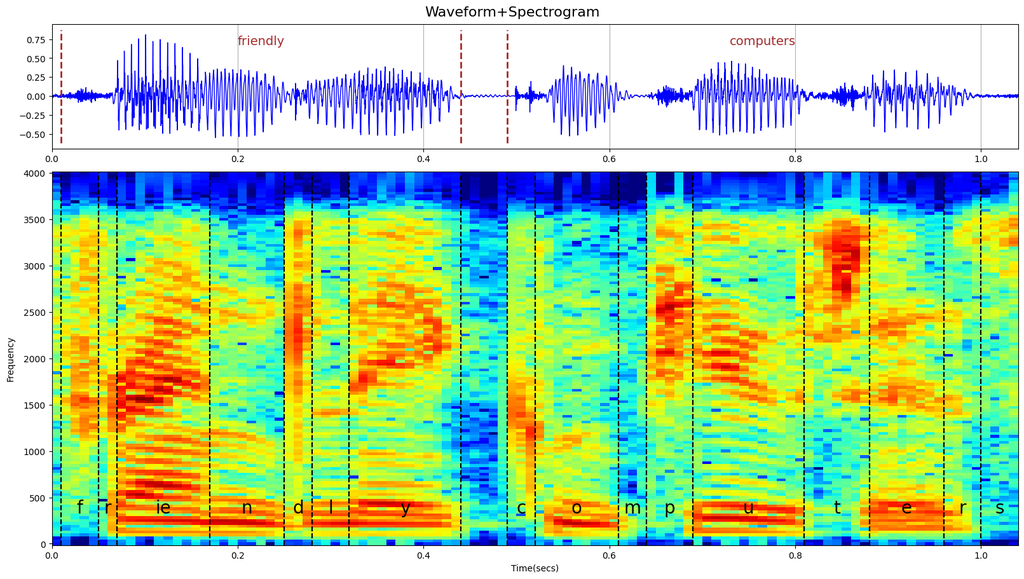

## 2. Sliding Window

We analyze speech by cutting it in successive frames, with a typical frame shift of 10 msec. For a number of signal processing reasons we use overlapping frames, i.e. frame length that is larger than the frame shift (eg 25msec). This will allow us to use a window that tapers toward the edges such as the Hamming window (used in the example below) to improve the quality of our spectral computation.

The figure below gives an illustration of the sliding window approach.

In the first illustration , you see how successive frames are cut out of a continuous signal. You can adjust 'i1' to give a different starting frame number and 'n' to give the number of successive frames in the plot.

In the second illustration you see the sliding window approach is used for spectrogram generation. You can adjust the frames variable to show a different part of the spectrogram.

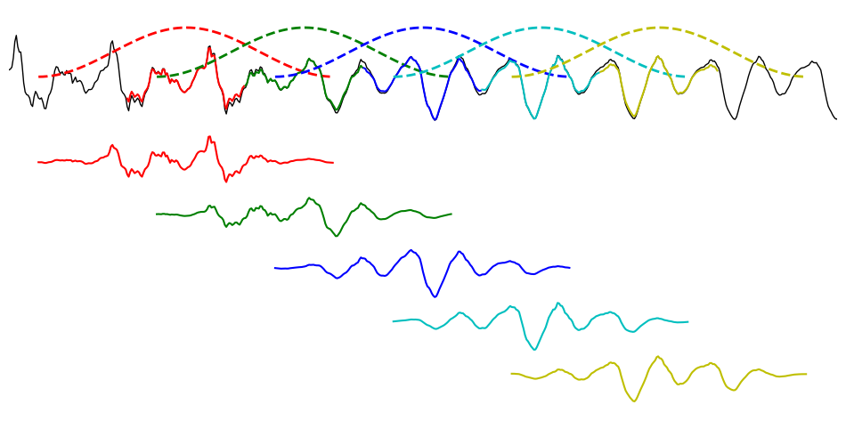

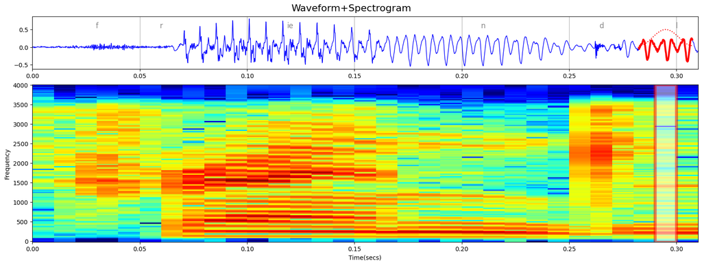